# Create Drop-Down Selection Lists

Rees Morrison

2023-01-18

When you ask a question on a survey and give respondents several answers to select from, you can present those selections in varied formats. Those choices of format do not change if the question allows for only a single choice or for multiple choices, e.g., “Choose all that apply.”

If you present survey-takers with only a few choices, you might spread them horizontally across the questionnaire page. Or you might list them vertically. With either format the person taking the survey can see all the answer possibilities at the same time, which makes their decisions easier. You can also create two lines of horizontal choices or two columns of vertical choices.

The screen shot below illustrates these format alternatives.

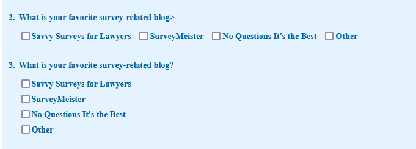

But at some number the selections become too many. Or the long scroll of selections ties up ugly amounts of intimidating screen space. Here is an instance I encountered. A law firm that was rethinking its Work from Home policies, arrived at a **ranking question** that included 16 potential advantages. We have considered above techniques to deal with the risk that the selections were so numerous that respondents might flag in their perusal of them, leading to **primacy bias** toward the first few selections being over chosen.

Assuming those techniques are not desirable, you could create a **drop-down** list containing the 16 selections.

One school of thought urges the designer of the drop-down list to put the most likely selection first, but that creates risks. The first few selections will be chosen more because respondents are busy or rushed and happy to seize the first plausible answer. You are influencing the findings. Sure, it’s more convenient for the respondents if you are right in privileging a certain answer at the top of the list, but you have lost accuracy and introduced a bias. It might make sense to put “United States” at the top of an alphabetical list of countries if the U.S. is the most likely choice, but otherwise stick to an alphabetical ordering.

Also with drop down lists, remind yourself to periodically study the comments and open text entries to determine whether you should add new entries. The whole idea, remember, is to standardize entries so that your analysis doesn’t suck up time on data wrangling so that your software can treat the answers as a manageable number of levels in the **factors**.

Some **hosting software** might enable users to search the drop-down list. You often see that for questions about states or countries. Type the first letter and then until you reach your desired answer. That would be a quite sophisticated capability of the software.

I have also learned that titles come in every conceivable variation. Rather than elongating the drop-down list, consider asking the respondents to pick “the nearest equivalent title.” An “Executive Director of Administration” would presumably be satisfied to check “Executive Director.”